# Data 607 Project2

Leticia Salazar

2021-10-05

#### The goal of this assignment is to give you practive in preparing different datasets for downstram analysis work.

#### Your task is to:

1. Choose any three of the “wide” datasets identified in the Week 6 Discussion items. (You may use your own dataset; please don’t use my Sample Post dataset, since that was used in your Week 6 assignment!) **For each of the three chosen datasets**
- Create a .CSV file (or optionally, a MySQL database!) that includes all of the information included in the dataset. You’re encouraged to use a “wide” structure similar to how the information appears in the discussion item, so that you can practice tidying and transformations as described below.
- Read the information from your .CSV file into R, and use tidyr and dplyr as needed to tidy and transform your data. [Most of your grade will be based on this step!]
- Perform the analysis requested in the discussion item.
- Your code should be in an R Markdown file, posted to rpubs.com, and should include narrative descriptions of your data cleanup work, analysis, and conclusions.
2. Please include in your homework submission, **for each of the three chosen datasets**:
- The URL to the .Rmd file in your GitHub repository, and
- The URL for your rpubs.com web page.

*Note: My collaborators (Chinedu and Tyler) and I were each responsible to tidy one data set which we would then share and join into our project 2. Below you’ll see the data set I chose to tidy.*

#### Load the Libraries

```r
#Import libraries
library(tidyverse)
```

```r
library(dplyr)
library(tidyr)
library(ggplot2)
library(hrbrthemes)
```

#### About the Dataset

##### The dataset was taken from Kaggle.com which was originally taken from an article called Hotel Booking Demands Datasets https://www.sciencedirect.com/science/article/pii/S2352340918315191.

#### It contains 32 columns listed below with a brief description:

[output not shown]

##### With this dataset I am looking to analyze the following:

- Cancellations of hotel with the arrival date month
- Cancellations of hotel with arrival date year

##### I would also like to analyze the following

- What type of hotels do repeated guest book?
- What type of customers tend to be repeated guests?
- Do repeated guests have a preferred meal choice?
- Do guests have special requests?
- How do total stays compare with total costs at hotels?

#### Load the data set

```r
theUrl <- "https://raw.githubusercontent.com/letisalba/Data607_Project2/main/hotel_bookings%202.csv"

hotel_booking <- read.csv(file = theUrl, header = TRUE, sep = ",")
head(hotel_booking)
```

```
##          hotel is_canceled lead_time arrival_date_year arrival_date_month
## 1 Resort Hotel           0       342              2015               July
## 2 Resort Hotel           0       737              2015               July
## 3 Resort Hotel           0         7              2015               July
## 4 Resort Hotel           0        13              2015               July
## 5 Resort Hotel           0        14              2015               July
## 6 Resort Hotel           0        14              2015               July
##   arrival_date_week_number arrival_date_day_of_month stays_in_weekend_nights
## 1                       27                         1                       0
## 2                       27                         1                       0
## 3                       27                         1                       0
## 4                       27                         1                       0
## 5                       27                         1                       0
## 6                       27                         1                       0
##   stays_in_week_nights adults children babies meal country market_segment
```

[output cut: 41 more lines]

### Data Wrangling

```r
#Get column names
colnames(hotel_booking)
```

```
##  [1] "hotel"                          "is_canceled"
##  [3] "lead_time"                      "arrival_date_year"
##  [5] "arrival_date_month"             "arrival_date_week_number"
##  [7] "arrival_date_day_of_month"      "stays_in_weekend_nights"
##  [9] "stays_in_week_nights"           "adults"
## [11] "children"                       "babies"
## [13] "meal"                           "country"
## [15] "market_segment"                 "distribution_channel"
## [17] "is_repeated_guest"              "previous_cancellations"
## [19] "previous_bookings_not_canceled" "reserved_room_type"
## [21] "assigned_room_type"             "booking_changes"
## [23] "deposit_type"                   "agent"
## [25] "company"                        "days_in_waiting_list"
## [27] "customer_type"                  "adr"
## [29] "required_car_parking_spaces"    "total_of_special_requests"
## [31] "reservation_status"             "reservation_status_date"
```

```r
#Rename column names for more clarity
colnames(hotel_booking) <-  c("Hotel", "Cancellation_Status", "Lead_Time", "Arrival_Year", "Arrival_Month", "Arrival_Week", "Arrival_Day_of_Month", "Stays_Weekend_Nights", "Stays_Week_Nights", "Adults", "Children", "Babies", "Meal", "Country", "Market_Segment", "Distribution_Channel", "Repeated_Guest", "Previous_Cancellations", "Prev_Non_Cancellations", "Reserved_Room", "Assigned_Room", "Booking_Changes", "Deposit_Type", "Agent", "Company", "Days_Waitlisted", "Customer_Type", "ADR", "Required_Parking_Spaces", "Special_Requests", "Reservation_Status", "Reservation_Status_Date")
head(hotel_booking)
```

```
##          Hotel Cancellation_Status Lead_Time Arrival_Year Arrival_Month
## 1 Resort Hotel                   0       342         2015          July
## 2 Resort Hotel                   0       737         2015          July
## 3 Resort Hotel                   0         7         2015          July
## 4 Resort Hotel                   0        13         2015          July
## 5 Resort Hotel                   0        14         2015          July
## 6 Resort Hotel                   0        14         2015          July
##   Arrival_Week Arrival_Day_of_Month Stays_Weekend_Nights Stays_Week_Nights
## 1           27                    1                    0                 0
## 2           27                    1                    0                 0
## 3           27                    1                    0                 1
## 4           27                    1                    0                 1
## 5           27                    1                    0                 2
## 6           27                    1                    0                 2
##   Adults Children Babies Meal Country Market_Segment Distribution_Channel
```

[output cut: 34 more lines]

```r
#Glimpse of data
glimpse(hotel_booking)
```

```
## Rows: 119,390
## Columns: 32
## $ Hotel                   <chr> "Resort Hotel", "Resort Hotel", "Resort Hotel"…
## $ Cancellation_Status     <int> 0, 0, 0, 0, 0, 0, 0, 0, 1, 1, 1, 0, 0, 0, 0, 0…
## $ Lead_Time               <int> 342, 737, 7, 13, 14, 14, 0, 9, 85, 75, 23, 35,…
## $ Arrival_Year            <int> 2015, 2015, 2015, 2015, 2015, 2015, 2015, 2015…
## $ Arrival_Month           <chr> "July", "July", "July", "July", "July", "July"…
## $ Arrival_Week            <int> 27, 27, 27, 27, 27, 27, 27, 27, 27, 27, 27, 27…
## $ Arrival_Day_of_Month    <int> 1, 1, 1, 1, 1, 1, 1, 1, 1, 1, 1, 1, 1, 1, 1, 1…
## $ Stays_Weekend_Nights    <int> 0, 0, 0, 0, 0, 0, 0, 0, 0, 0, 0, 0, 0, 0, 0, 0…
## $ Stays_Week_Nights       <int> 0, 0, 1, 1, 2, 2, 2, 2, 3, 3, 4, 4, 4, 4, 4, 4…
## $ Adults                  <int> 2, 2, 1, 1, 2, 2, 2, 2, 2, 2, 2, 2, 2, 2, 2, 2…
## $ Children                <int> 0, 0, 0, 0, 0, 0, 0, 0, 0, 0, 0, 0, 0, 1, 0, 0…
## $ Babies                  <int> 0, 0, 0, 0, 0, 0, 0, 0, 0, 0, 0, 0, 0, 0, 0, 0…
## $ Meal                    <chr> "BB", "BB", "BB", "BB", "BB", "BB", "BB", "FB"…
```

[output cut: 19 more lines]

```r
#Summary of columns in data
summary(hotel_booking)
```

```
##     Hotel           Cancellation_Status   Lead_Time    Arrival_Year
##  Length:119390      Min.   :0.0000      Min.   :  0   Min.   :2015
##  Class :character   1st Qu.:0.0000      1st Qu.: 18   1st Qu.:2016
##  Mode  :character   Median :0.0000      Median : 69   Median :2016
##                     Mean   :0.3704      Mean   :104   Mean   :2016
##                     3rd Qu.:1.0000      3rd Qu.:160   3rd Qu.:2017
##                     Max.   :1.0000      Max.   :737   Max.   :2017
##
##  Arrival_Month       Arrival_Week   Arrival_Day_of_Month Stays_Weekend_Nights
##  Length:119390      Min.   : 1.00   Min.   : 1.0         Min.   : 0.0000
##  Class :character   1st Qu.:16.00   1st Qu.: 8.0         1st Qu.: 0.0000
##  Mode  :character   Median :28.00   Median :16.0         Median : 1.0000
##                     Mean   :27.17   Mean   :15.8         Mean   : 0.9276
##                     3rd Qu.:38.00   3rd Qu.:23.0         3rd Qu.: 2.0000
##                     Max.   :53.00   Max.   :31.0         Max.   :19.0000
##
##  Stays_Week_Nights     Adults          Children           Babies
##  Min.   : 0.0      Min.   : 0.000   Min.   : 0.0000   Min.   : 0.000000
##  1st Qu.: 1.0      1st Qu.: 2.000   1st Qu.: 0.0000   1st Qu.: 0.000000
##  Median : 2.0      Median : 2.000   Median : 0.0000   Median : 0.000000
##  Mean   : 2.5      Mean   : 1.856   Mean   : 0.1039   Mean   : 0.007949
##  3rd Qu.: 3.0      3rd Qu.: 2.000   3rd Qu.: 0.0000   3rd Qu.: 0.000000
##  Max.   :50.0      Max.   :55.000   Max.   :10.0000   Max.   :10.000000
##                                     NA's   :4
##      Meal             Country          Market_Segment     Distribution_Channel
##  Length:119390      Length:119390      Length:119390      Length:119390
##  Class :character   Class :character   Class :character   Class :character
##  Mode  :character   Mode  :character   Mode  :character   Mode  :character
##
##
##
##
##  Repeated_Guest    Previous_Cancellations Prev_Non_Cancellations
##  Min.   :0.00000   Min.   : 0.00000       Min.   : 0.0000
##  1st Qu.:0.00000   1st Qu.: 0.00000       1st Qu.: 0.0000
##  Median :0.00000   Median : 0.00000       Median : 0.0000
##  Mean   :0.03191   Mean   : 0.08712       Mean   : 0.1371
##  3rd Qu.:0.00000   3rd Qu.: 0.00000       3rd Qu.: 0.0000
##  Max.   :1.00000   Max.   :26.00000       Max.   :72.0000
##
```

[output cut: 17 more lines]

```
##  Min.   :  -6.38   Min.   :0.00000         Min.   :0.0000   Length:119390
##  1st Qu.:  69.29   1st Qu.:0.00000         1st Qu.:0.0000   Class :character
##  Median :  94.58   Median :0.00000         Median :0.0000   Mode  :character
##  Mean   : 101.83   Mean   :0.06252         Mean   :0.5714
##  3rd Qu.: 126.00   3rd Qu.:0.00000         3rd Qu.:1.0000
##  Max.   :5400.00   Max.   :8.00000         Max.   :5.0000
##
##  Reservation_Status_Date
##  Length:119390
##  Class :character
##  Mode  :character
##
##
##
##
```

```r
#Convert columns to factor
hotel_bookings <- hotel_booking %>%
   mutate(Cancellation_Status = as.factor(Cancellation_Status),
          Meal = as.factor(Meal),
          Repeated_Guest = as.factor(Repeated_Guest),
         )
head(hotel_booking, n = 4)
```

```
##          Hotel Cancellation_Status Lead_Time Arrival_Year Arrival_Month
## 1 Resort Hotel                   0       342         2015          July
## 2 Resort Hotel                   0       737         2015          July
## 3 Resort Hotel                   0         7         2015          July
## 4 Resort Hotel                   0        13         2015          July
##   Arrival_Week Arrival_Day_of_Month Stays_Weekend_Nights Stays_Week_Nights
## 1           27                    1                    0                 0
## 2           27                    1                    0                 0
## 3           27                    1                    0                 1
## 4           27                    1                    0                 1
##   Adults Children Babies Meal Country Market_Segment Distribution_Channel
## 1      2        0      0   BB     PRT         Direct               Direct
## 2      2        0      0   BB     PRT         Direct               Direct
## 3      1        0      0   BB     GBR         Direct               Direct
## 4      1        0      0   BB     GBR      Corporate            Corporate
```

[output cut: 20 more lines]

```r
#Calculate total cost of stays and the total number of stays for each reservation and create two separate columns for each

hotel_bookings <- hotel_booking %>%
  mutate(Stays_Total = Stays_Weekend_Nights + Stays_Week_Nights,
       Stays_Total_Cost = ADR * Stays_Total)
head(hotel_bookings, n = 4)
```

```
##          Hotel Cancellation_Status Lead_Time Arrival_Year Arrival_Month
## 1 Resort Hotel                   0       342         2015          July
## 2 Resort Hotel                   0       737         2015          July
## 3 Resort Hotel                   0         7         2015          July
## 4 Resort Hotel                   0        13         2015          July
##   Arrival_Week Arrival_Day_of_Month Stays_Weekend_Nights Stays_Week_Nights
## 1           27                    1                    0                 0
## 2           27                    1                    0                 0
## 3           27                    1                    0                 1
## 4           27                    1                    0                 1
##   Adults Children Babies Meal Country Market_Segment Distribution_Channel
## 1      2        0      0   BB     PRT         Direct               Direct
## 2      2        0      0   BB     PRT         Direct               Direct
## 3      1        0      0   BB     GBR         Direct               Direct
## 4      1        0      0   BB     GBR      Corporate            Corporate
```

[output cut: 20 more lines]

```r
#Find missing values
colSums(is.na(hotel_bookings))
```

```
##                   Hotel     Cancellation_Status               Lead_Time
##                       0                       0                       0
##            Arrival_Year           Arrival_Month            Arrival_Week
##                       0                       0                       0
##    Arrival_Day_of_Month    Stays_Weekend_Nights       Stays_Week_Nights
##                       0                       0                       0
##                  Adults                Children                  Babies
##                       0                       4                       0
##                    Meal                 Country          Market_Segment
##                       0                       0                       0
##    Distribution_Channel          Repeated_Guest  Previous_Cancellations
##                       0                       0                       0
##  Prev_Non_Cancellations           Reserved_Room           Assigned_Room
##                       0                       0                       0
##         Booking_Changes            Deposit_Type                   Agent
##                       0                       0                       0
##                 Company         Days_Waitlisted           Customer_Type
##                       0                       0                       0
##                     ADR Required_Parking_Spaces        Special_Requests
##                       0                       0                       0
##      Reservation_Status Reservation_Status_Date             Stays_Total
##                       0                       0                       0
##        Stays_Total_Cost
##                       0
```

```r
#There are 4 values missing in children
```

```r
#Replace missing values in Children by using the Median
#By using the Median it will allow for those missing values to be added without trying to guess what number to input. Using the number 0 would have also worked without skewing the data.

children_median <- median(hotel_bookings$Children, na.rm = TRUE)

hotel_bookings$Children[is.na(hotel_bookings$Children)] <- children_median

head(hotel_bookings, n = 4)
```

```
##          Hotel Cancellation_Status Lead_Time Arrival_Year Arrival_Month
## 1 Resort Hotel                   0       342         2015          July
## 2 Resort Hotel                   0       737         2015          July
## 3 Resort Hotel                   0         7         2015          July
## 4 Resort Hotel                   0        13         2015          July
##   Arrival_Week Arrival_Day_of_Month Stays_Weekend_Nights Stays_Week_Nights
## 1           27                    1                    0                 0
## 2           27                    1                    0                 0
## 3           27                    1                    0                 1
## 4           27                    1                    0                 1
##   Adults Children Babies Meal Country Market_Segment Distribution_Channel
## 1      2        0      0   BB     PRT         Direct               Direct
## 2      2        0      0   BB     PRT         Direct               Direct
## 3      1        0      0   BB     GBR         Direct               Direct
## 4      1        0      0   BB     GBR      Corporate            Corporate
```

[output cut: 20 more lines]

```r
#Check to see if there's any other missing values
colSums(is.na(hotel_bookings))
```

```
##                   Hotel     Cancellation_Status               Lead_Time
##                       0                       0                       0
##            Arrival_Year           Arrival_Month            Arrival_Week
##                       0                       0                       0
##    Arrival_Day_of_Month    Stays_Weekend_Nights       Stays_Week_Nights
##                       0                       0                       0
##                  Adults                Children                  Babies
##                       0                       0                       0
##                    Meal                 Country          Market_Segment
##                       0                       0                       0
##    Distribution_Channel          Repeated_Guest  Previous_Cancellations
##                       0                       0                       0
##  Prev_Non_Cancellations           Reserved_Room           Assigned_Room
##                       0                       0                       0
##         Booking_Changes            Deposit_Type                   Agent
##                       0                       0                       0
##                 Company         Days_Waitlisted           Customer_Type
##                       0                       0                       0
##                     ADR Required_Parking_Spaces        Special_Requests
##                       0                       0                       0
##      Reservation_Status Reservation_Status_Date             Stays_Total
##                       0                       0                       0
##        Stays_Total_Cost
##                       0
```

```r
#Replace all NULL values in data set
hotel_bookings2 <- hotel_bookings %>% replace(.=="NULL", 0) # replace with 0
head(hotel_bookings2, n = 4)
```

```
##          Hotel Cancellation_Status Lead_Time Arrival_Year Arrival_Month
## 1 Resort Hotel                   0       342         2015          July
## 2 Resort Hotel                   0       737         2015          July
## 3 Resort Hotel                   0         7         2015          July
## 4 Resort Hotel                   0        13         2015          July
##   Arrival_Week Arrival_Day_of_Month Stays_Weekend_Nights Stays_Week_Nights
## 1           27                    1                    0                 0
## 2           27                    1                    0                 0
## 3           27                    1                    0                 1
## 4           27                    1                    0                 1
##   Adults Children Babies Meal Country Market_Segment Distribution_Channel
## 1      2        0      0   BB     PRT         Direct               Direct
## 2      2        0      0   BB     PRT         Direct               Direct
## 3      1        0      0   BB     GBR         Direct               Direct
## 4      1        0      0   BB     GBR      Corporate            Corporate
```

[output cut: 20 more lines]

```r
#Replacing values in Cancellation_Status column so that 0 = not cancelled and 1 = cancelled
hotel_bookings3<- recode(hotel_bookings2$Cancellation_Status,
                              "0" = "Not_Cancelled",
                              "1" = "Cancelled")
head(hotel_bookings3)
```

```
## [1] "Not_Cancelled" "Not_Cancelled" "Not_Cancelled" "Not_Cancelled"
## [5] "Not_Cancelled" "Not_Cancelled"
```

```r
#Replacing values in Repeated_Guest column so that 0 = new guest and 1 = repeated guest
hotel_bookings4 <- recode(hotel_bookings2$Repeated_Guest,
                              "0" = "New_Guest",
                              "1" = "Repeated_Guest")
head(hotel_bookings4)
```

```
## [1] "New_Guest" "New_Guest" "New_Guest" "New_Guest" "New_Guest" "New_Guest"
```

```r
#cbind 3 tables
hotelbookings <-  cbind(hotel_bookings2, hotel_bookings3, hotel_bookings4)

#Drop rows not needed
hotelbookings <- hotelbookings[, -c(2, 15:17, 20, 21, 23:25, 29, 32)]

head(hotelbookings)
```

```
##          Hotel Lead_Time Arrival_Year Arrival_Month Arrival_Week
## 1 Resort Hotel       342         2015          July           27
## 2 Resort Hotel       737         2015          July           27
## 3 Resort Hotel         7         2015          July           27
## 4 Resort Hotel        13         2015          July           27
## 5 Resort Hotel        14         2015          July           27
## 6 Resort Hotel        14         2015          July           27
##   Arrival_Day_of_Month Stays_Weekend_Nights Stays_Week_Nights Adults Children
## 1                    1                    0                 0      2        0
## 2                    1                    0                 0      2        0
## 3                    1                    0                 1      1        0
## 4                    1                    0                 1      1        0
## 5                    1                    0                 2      2        0
## 6                    1                    0                 2      2        0
##   Babies Meal Country Previous_Cancellations Prev_Non_Cancellations
```

[output cut: 27 more lines]

```r
#Get column names
colnames(hotelbookings)
```

```
##  [1] "Hotel"                  "Lead_Time"              "Arrival_Year"
##  [4] "Arrival_Month"          "Arrival_Week"           "Arrival_Day_of_Month"
##  [7] "Stays_Weekend_Nights"   "Stays_Week_Nights"      "Adults"
## [10] "Children"               "Babies"                 "Meal"
## [13] "Country"                "Previous_Cancellations" "Prev_Non_Cancellations"
## [16] "Booking_Changes"        "Days_Waitlisted"        "Customer_Type"
## [19] "ADR"                    "Special_Requests"       "Reservation_Status"
## [22] "Stays_Total"            "Stays_Total_Cost"       "hotel_bookings3"
## [25] "hotel_bookings4"
```

```r
#Rename column names
colnames(hotelbookings) <-  c("Hotel", "Lead_Time", "Arrival_Year", "Arrival_Month", "Arrival_Week", "Arrival_Day_of_Month", "Stays_Weekend_Nights", "Stays_Week_Nights", "Adults", "Children", "Babies", "Meal", "Country", "Previous_Cancellations", "Prev_Non_Cancellations", "Booking_Changes", "Days_Waitlisted", "Customer_Type", "ADR", "Special_Requests", "Reservation_Status", "Stays_Total", "Stays_Total_Cost", "Cancellation_Status", "Is_Repeated_Guest")

#Reorder columns
col_order <- c("Hotel", "Cancellation_Status", "Lead_Time", "Arrival_Year", "Arrival_Month", "Arrival_Week", "Arrival_Day_of_Month", "Stays_Weekend_Nights", "Stays_Week_Nights", "Stays_Total", "Stays_Total_Cost", "Adults", "Children", "Babies", "Meal", "Country", "Is_Repeated_Guest", "Previous_Cancellations", "Prev_Non_Cancellations", "Booking_Changes", "Days_Waitlisted", "Customer_Type", "ADR", "Special_Requests", "Reservation_Status")

hotelbookings <- hotelbookings[, col_order]
head(hotelbookings)
```

```
##          Hotel Cancellation_Status Lead_Time Arrival_Year Arrival_Month
## 1 Resort Hotel       Not_Cancelled       342         2015          July
## 2 Resort Hotel       Not_Cancelled       737         2015          July
## 3 Resort Hotel       Not_Cancelled         7         2015          July
## 4 Resort Hotel       Not_Cancelled        13         2015          July
## 5 Resort Hotel       Not_Cancelled        14         2015          July
## 6 Resort Hotel       Not_Cancelled        14         2015          July
##   Arrival_Week Arrival_Day_of_Month Stays_Weekend_Nights Stays_Week_Nights
## 1           27                    1                    0                 0
## 2           27                    1                    0                 0
## 3           27                    1                    0                 1
## 4           27                    1                    0                 1
## 5           27                    1                    0                 2
## 6           27                    1                    0                 2
##   Stays_Total Stays_Total_Cost Adults Children Babies Meal Country
```

[output cut: 27 more lines]

### Data Exploration

##### **City Hotels have the hightest number of bookings**

```r
#Count of Hotels
Hotel <- hotel_bookings2%>%
  group_by(Hotel)%>%
  summarise(num=n())%>%
  arrange(desc(num))
head(Hotel)
```

```
## # A tibble: 2 × 2
##   Hotel          num
##   <chr>        <int>
## 1 City Hotel   79330
## 2 Resort Hotel 40060
```

##### **There has been more non cancellations than cancellations when booking**

```r
#Count of Cancellation_Status
Cancellation_Status <- hotel_bookings2%>%
  group_by(Cancellation_Status)%>%
  summarise(num=n())%>%
  arrange(desc(num))
head(Cancellation_Status)
```

```
## # A tibble: 2 × 2
##   Cancellation_Status   num
##                 <int> <int>
## 1                   0 75166
## 2                   1 44224
```

##### **August and July are the two highest months when hotels are booked**

```r
#Count of Arrival_Month
Arrival_Month <- hotel_bookings2%>%
  group_by(Arrival_Month)%>%
  summarise(num=n())%>%
  arrange(desc(num))
head(Arrival_Month)
```

```
## # A tibble: 6 × 2
##   Arrival_Month   num
##   <chr>         <int>
## 1 August        13877
## 2 July          12661
## 3 May           11791
## 4 October       11160
## 5 April         11089
## 6 June          10939
```

##### **Zero and two weekend nights are amongst the highest guest have stayed in a hotel**

```r
#Count of Stays_Weekend_Nights
Stays_Weekend <- hotel_bookings2%>%
  group_by(Stays_Weekend_Nights)%>%
  summarise(num=n())%>%
  arrange(desc(num))
head(Stays_Weekend)
```

```
## # A tibble: 6 × 2
##   Stays_Weekend_Nights   num
##                  <int> <int>
## 1                    0 51998
## 2                    2 33308
## 3                    1 30626
## 4                    4  1855
## 5                    3  1259
## 6                    6   153
```

##### **Two and one week nights are the most guest stay or book to stay at the hotel.**

```r
#Count of Stays_Week_Nights
Stays_Week <- hotel_bookings2%>%
  group_by(Stays_Week_Nights)%>%
  summarise(num=n())%>%
  arrange(desc(num))
head(Stays_Week)
```

```
## # A tibble: 6 × 2
##   Stays_Week_Nights   num
##               <int> <int>
## 1                 2 33684
## 2                 1 30310
## 3                 3 22258
## 4                 5 11077
## 5                 4  9563
## 6                 0  7645
```

##### **Bed and Breakfast is the most common meal option.**

```r
#Count of Meals
Meal <- hotel_bookings2%>%
  group_by(Meal)%>%
  summarise(num=n())%>%
  arrange(desc(num))
head(Meal)
```

```
## # A tibble: 5 × 2
##   Meal        num
##   <chr>     <int>
## 1 BB        92310
## 2 HB        14463
## 3 SC        10650
## 4 Undefined  1169
## 5 FB          798
```

##### **Non repeated guest tend to book stays more often than repeated guests.**

```r
#Count of Repeated_Guest
Repeated_Guest <- hotel_bookings2%>%
  group_by(Repeated_Guest)%>%
  summarise(num=n())%>%
  arrange(desc(num))
head(Repeated_Guest)
```

```
## # A tibble: 2 × 2
##   Repeated_Guest    num
##            <int>  <int>
## 1              0 115580
## 2              1   3810
```

##### **Transient customers book the most hotel stays..**

```r
#Count on Customer_Type
Customer <- hotel_bookings2%>%
  group_by(Customer_Type)%>%
  summarise(num=n())%>%
  arrange(desc(num))
head(Customer)
```

```
## # A tibble: 4 × 2
##   Customer_Type     num
##   <chr>           <int>
## 1 Transient       89613
## 2 Transient-Party 25124
## 3 Contract         4076
## 4 Group             577
```

##### **Zero and 1 special requests are made by the customer**

```r
#Count on Special_Requests
Special_Requests <- hotel_bookings2%>%
  group_by(Special_Requests)%>%
  summarise(num=n())%>%
  arrange(desc(num))
head(Special_Requests)
```

```
## # A tibble: 6 × 2
##   Special_Requests   num
##              <int> <int>
## 1                0 70318
## 2                1 33226
## 3                2 12969
## 4                3  2497
## 5                4   340
## 6                5    40
```

##### **When combining the stays for weekend nights and week nights, the two days is the highest number of stays.**

```r
#Count on Stays_Total
Stays_Total <- hotel_bookings2%>%
  group_by(Stays_Total)%>%
  summarise(num=n())%>%
  arrange(desc(num))
head(Stays_Total)
```

```
## # A tibble: 6 × 2
##   Stays_Total   num
##         <int> <int>
## 1           2 27643
## 2           3 27076
## 3           1 21020
## 4           4 17383
## 5           7  8655
## 6           5  7784
```

##### **The most common total cost in a hotel stay is $124 (assuming the currency is dollars)**

```r
#Count on Stays_Total_Cost
Stays_Total_Cost <- hotel_bookings2%>%
  group_by(Stays_Total_Cost)%>%
  summarise(num=n())%>%
  arrange(desc(num))
head(Stays_Total_Cost)
```

```
## # A tibble: 6 × 2
##   Stays_Total_Cost   num
##              <dbl> <int>
## 1              124  2913
## 2                0  1959
## 3              180  1310
## 4              270  1090
## 5              240  1046
## 6              300  1030
```

### Data Analysis:

##### Cancellations of hotel with Arrival Month

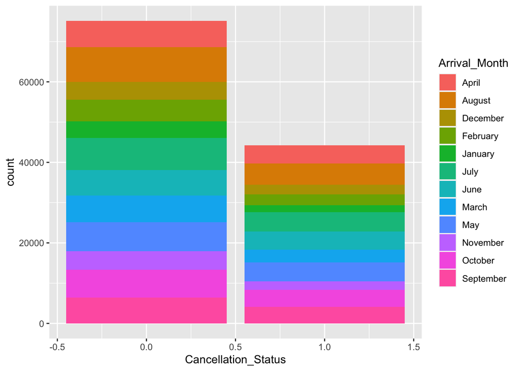

```r
# Bar Plot
hotel_bookings2 %>%
ggplot(aes(x = Cancellation_Status, fill = Arrival_Month)) +
  geom_bar()
```

##### Cancellations of hotel with arrival date year

*The year 2016 had the most cancellations/non-cancellations.*

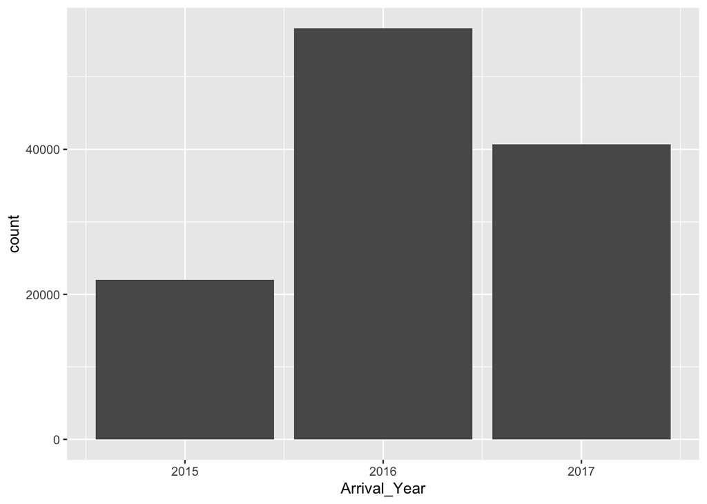

```r
# Bar Plot
hotel_bookings2 %>%
ggplot(aes(x = Arrival_Year, fill = Cancellation_Status)) +
  geom_bar()
```

##### What type of hotels do repeated guest book?

*Repeated guests book City Hotels the most.*

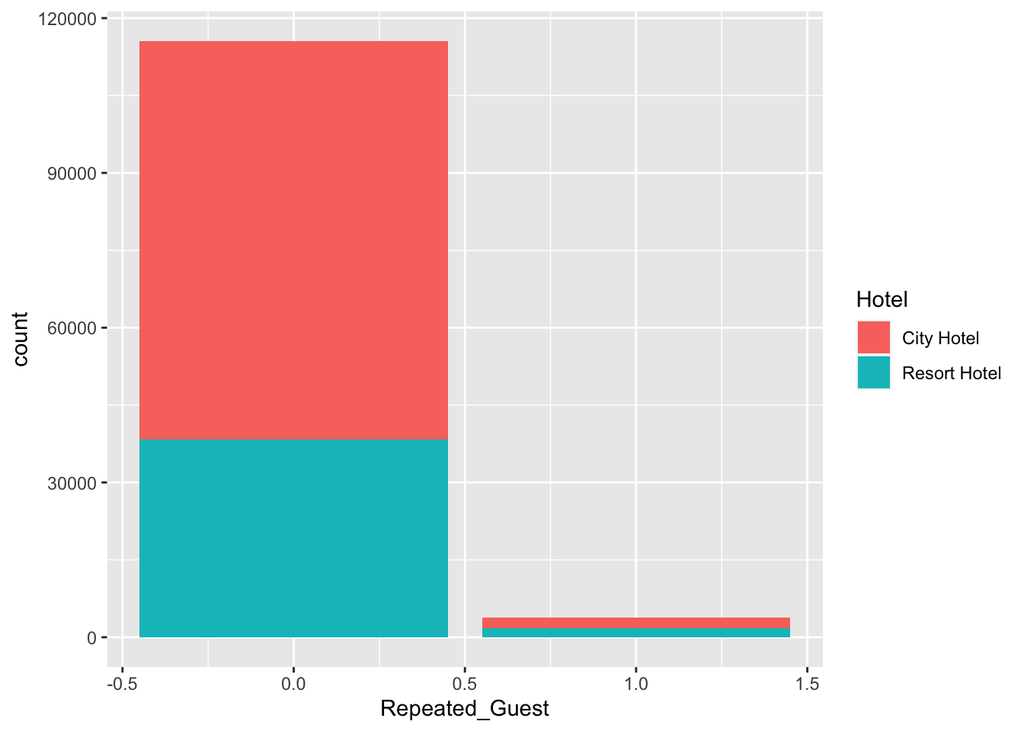

```r
# Bar Plot
hotel_bookings2 %>%
ggplot(aes(x = Repeated_Guest, fill = Hotel)) +
  geom_bar()
```

##### What type of customers tend to be repeated guests?

*Transient customers tend to be repeated guests.*

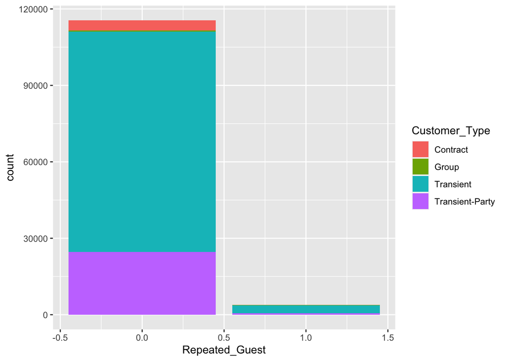

```r
# Plot
hotel_bookings2%>%
  ggplot(aes(x = Repeated_Guest, fill = Customer_Type)) +
  geom_bar()
```

##### Do repeated guests have a preferred meal choice?

*Bed and Breakfast is the preferred meal of choice for repeated guest.*

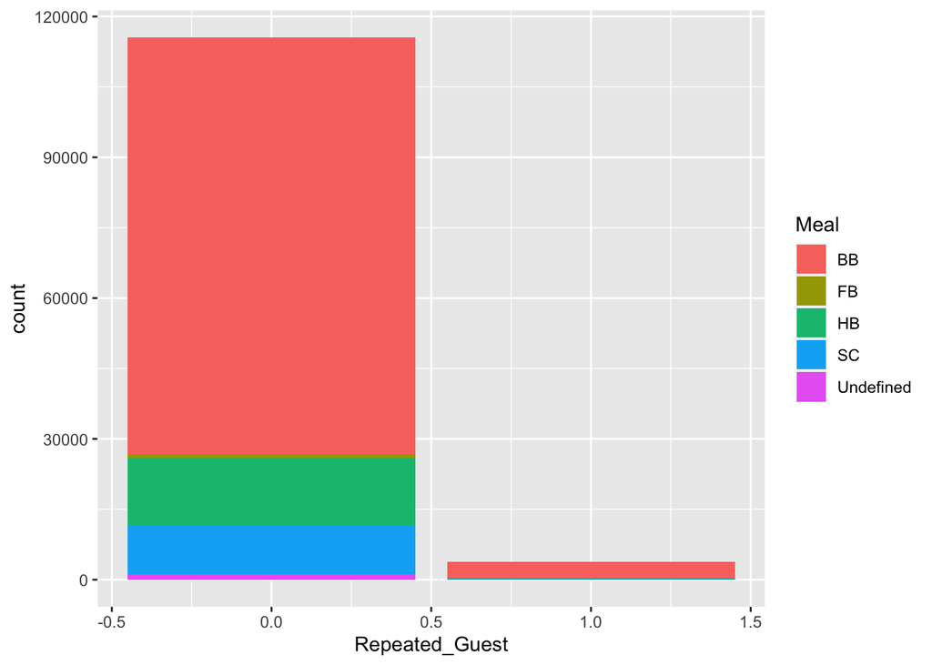

```r
# Plot
hotel_bookings2%>%
  ggplot(aes(x = Repeated_Guest, fill = Meal)) +
  geom_bar()
```

##### Do guests have special requests?

*Guests in general have no special requests during hotel stay.*

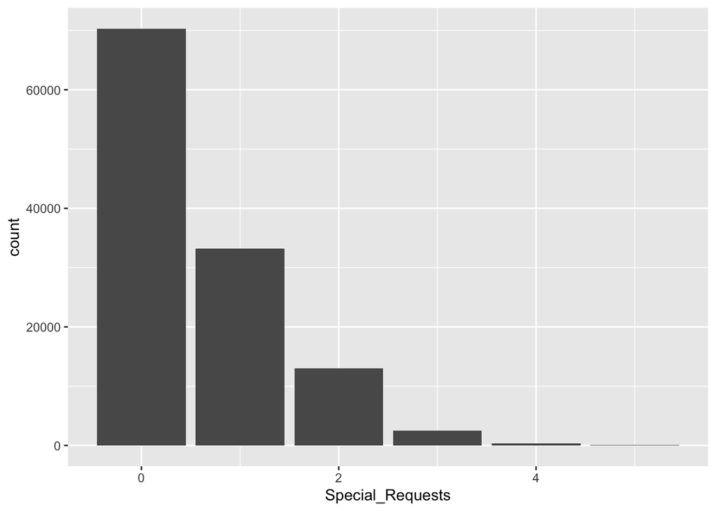

```r
# Plot
hotel_bookings2%>%
  ggplot(aes(x = Special_Requests, fill = Repeated_Guest)) +
  geom_bar()
```

##### How do total stays compare with total costs at hotels?

*Whether it’s a City or Resort hotel, majority of the booking stays are between 0 to 20 days with a few outliers.*

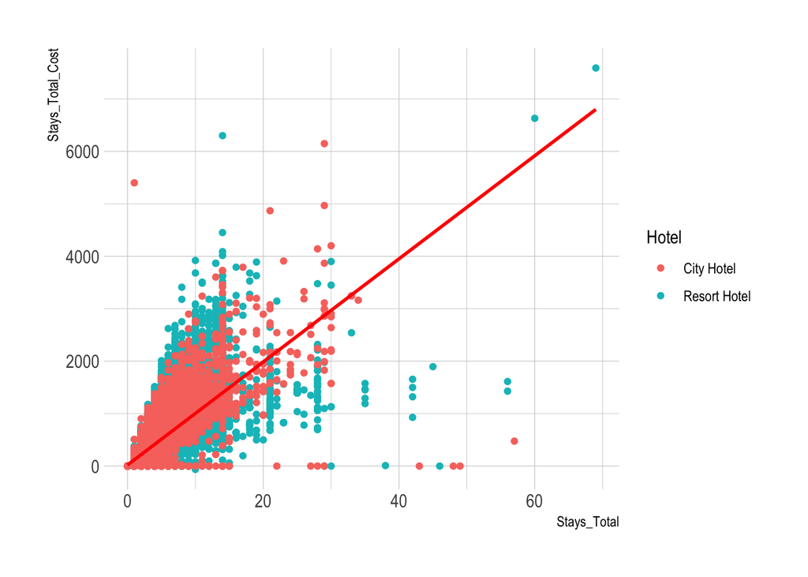

```r
#Scatter plot
hotel_bookings2 %>%
ggplot(aes(x = Stays_Total, y = Stays_Total_Cost, color = Hotel)) +
  geom_point() +
  geom_smooth(formula = y ~ x, method=lm , color="red", se=FALSE) + # with linear trend
  theme_ipsum()
```